# wrangle_act-Copy1

## Project: The WeRateDogs Twitter Archive

Author: Piyush Kumar

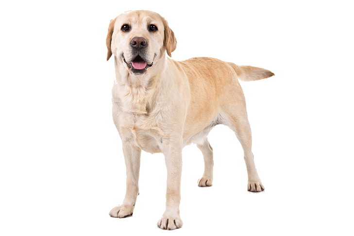

### Introduction:

The dataset that we will be wrangling (and analyzing and visualizing) is the tweet archive of Twitter user @dog_rates, also known as WeRateDogs. WeRateDogs is a Twitter account that rates people's dogs with a humorous comment about the dog. These ratings almost always have a denominator of 10. The numerators, though? Almost always greater than 10. 11/10, 12/10, 13/10, etc. Why? Because "they're good dogs Brent." WeRateDogs has over 4 million followers and has received international media coverage.

#### The Data:

- **Twitter Archive:** Twitter archive obtained from WeRateDogs contains the basic twitter data of the WeRateDogs account. Some re-engineering was done beforehand to extract the rating, dog name and dog stage from each tweet's text, which makes this twitter archive 'enhanced.'
- **Image Predictions File:** It contains the predictions of the dog breed from the image, obtained through a neural network that was ran through the twiiter archive of WeRateDogs account.
- **Twitter API:** Retweet count and favorite count are two of the notable column omissions in the twitter archive. Fortunately, this additional data can be gathered by querying the Twitter's API for each tweet's JSON data using Python's Tweepy library. We would also be able to pull other attributes such as followers count, friends count and more.

#### Let' checkout a tweet from WeRateDogs twitter handle.

> This is Skipper. He's been shipwrecked. Was wondering if you could help him get his boat back to sea so he may resume his voyage. 14/10 [pic.twitter.com/1bhjvXekRr](https://t.co/1bhjvXekRr)

> — WeRateDogs® (@dog_rates) [March 5, 2020](https://twitter.com/dog_rates/status/1235371660439482369?ref_src=twsrc%5Etfw)

### Asessed and Cleaned:

**1. Twitter Archive**

**Let's describe these columns briefly:**

- **tweet_id:** the unique identifier for each of the tweet
- **in_reply_to_status_id:** If the represented tweet is a reply, this field contains the original tweet’s ID.
- **in_reply_to_user_id:** If the represented tweet is a reply, this field contains the original tweet author's ID.
- **timestamp:** UTC time when the tweet was created.
- **source:** Utility used to post the Tweet, as an HTML-formatted string.
- **text:** The actual UTF-8 text of the status update.
- **retweeted_status_id:** If the represented tweet is a reply, this field contains the retweeted tweet's ID.
- **retweeted_status_user_id:** If the represented tweet is a reply, this field contains the retweeted tweet's author ID.
- **retweeted_status_timestamp:** If the represented tweet is a reply, this field contains the UTC time when the retweeted was created.
- **expanded_urls:** An expanded version of URL of the media to display to clients.
- **rating_numerator:** the ranking given to the dog in tweet.
- **rating_denominator:** the reference ranking
- **name:** the dog's name
- **doggo, floofer, pupper, puppo:** stage of the dog

More information on this can be found on [Twitter Developer Docs](https://developer.twitter.com/en/docs/tweets/data-dictionary/overview/intro-to-tweet-json#dictionaries).

#### Quality: `archive`

- **source** column contains unnecessary HTML markups.
- The columns **in_reply_to_status_id**, **in_reply_to_user_id**, **retweeted_status_id**, **retweeted_status_user_id**, **retweeted_status_timestamp** are of incorrect data type. Furthermore, they have lot of missing values, these columns are not much of significance for our analysis.
- In **timestamp** column '+0000' is redundant information.
- **tweet_id** should be of object data type instead of int, as we never do a mathematical operation on IDs.
- **timestamp** should be datetime type instead of object.
- Dog stage variables: **doggo, floofer, pupper, puppo:** has **None** as the placeholder for the missing value instead of pythonic NaN.
- **name** column also has **None** as the placeholder for missing values instead of NaN. And, there are lot of missing values.
- We have noticed very inappropriate dog **name** like a, an, the, very, this, his, by, my, all, not, O, such, just etc.
- We have inappropriate values for **rating_numerator** going above 20 and upto 1776, and even being 0 at times.
- Similary, we have such outliers for **rating_denominator** values too, **rating_denominator** values being greater than 10 for a good no. of times.

#### Tidiness: `archive`

- One tweet_id and all the associated information is one observation but it doesn't form a row in our **`archive`** dataframe i.e there are other attributes associated with each tweet id which are in other datasets **`img-predictions`** and **`tweet_info`**.
- dog stage is a variable but it doesn't form a column and is panning out in four columns (**doggo, floofer, pupper, puppo**) instead.

#### 2. Image Predictions File

**Let's understand these columns more:**

- **tweet_id:** tweet_id is the last part of the tweet URL after "status/"
- **jpg_url:** Image link or URL
- **img_num:** Image number that corresponded to the most confident prediction (numbered 1 to 4 since tweets can have up to four images)
- **p1:** p1 is the algorithm's #1 prediction for the image in the tweet
- **p1_conf:** p1_conf is how confident the algorithm is in its #1 prediction
- **p1_dog:** p1_dog is whether or not the #1 prediction is a breed of dog
- **p2:** is the algorithm's second most likely prediction
- **p2_conf:** is how confident the algorithm is in its #2 prediction
- **p2_dog:** is whether or not the #2 prediction is a breed of dog
- **p3:** p3 is the algorithm's #3 prediction for the image in the tweet
- **p3_conf:** p3_conf is how confident the algorithm is in its #3 prediction
- **p3_dog:** p3_dog is whether or not the #3 prediction is a breed of dog

#### Let's look at few of the breed predictions made by the Image classifier neural network.

[figure not shown]

```
'restaurant'
```

[figure not shown]

```
'Shih-Tzu'
```

[figure not shown]

```
'West_Highland_white_terrier'
```

[figure not shown]

```
'barrow'
```

[figure not shown]

```
'English_springer'
```

#### Now, let's look at the predictions classified as not a dog, to see if it's actually not a dog in the image.

[figure not shown]

```
'jigsaw_puzzle'
```

[figure not shown]

```
'tub'
```

[figure not shown]

```
'motor_scooter'
```

[figure not shown]

```
'snorkel'
```

[figure not shown]

```
'geyser'
```

[figure not shown]

```
'washbasin'
```

- Predictions are entirely wrong for few of the images fed to the neural network.

#### Quality: **`img_predictions`**

- We have image predictions for 2075 tweets only.
- **tweet_id** should be of object data type instead of int, as we never do a mathematical operation on IDs.
- Columns **p1**, **p2** and **p3** have breed names with inconsistent writings.
- Few of the images fed to the neural network are misclassified as not a breed of dog.

#### Tidiness: **`img_predictions`**

- The prediction results for each **tweet id** in **`img_predictions`** should be merged with **`archive`** to better represent each observation and confirm with the definition of tidiness.

#### 3. Additional Data Via Twitter API

#### Quality: **`tweet_info`**

- Again, **tweet_id** should be of object data type instead of int, as we never do a mathematical operation on IDs.
- **followers_count**, **retweet_count**, **likes**, **friends_count** should be of int data type instead of object and **created_at** column should be of datetime type.
- We have additional tweet info viz., **followers_count**, **retweet_count**, **likes**, **friends_count** for 2331 tweets only.
- In **created_at** column '+0000' is redundant information.

#### Tidiness: **`tweet_info`**

- All the columns except **created_at** (as we already have a timestamp in **`archive`**) **retweet_count**, **likes**, **followers_count** and **friends_count** should be merged with **`archive`** dataset to confirm with the definition of tidiness.
- The rating system of **@WeRateDogs** is unique to them. We do not have much background info on the rating system adopted by them, outliers in the **rating_numerator** and **rating_denominator** values could also be the result of humerous rating adopted by them. Also, tweets of **@WeRateDogs** account do intend to provide some humerous pinch with the tweet. So, we will leave the rating system as is.

### Analyzing and Visualizing Data

#### 1. What are the most common dog names?

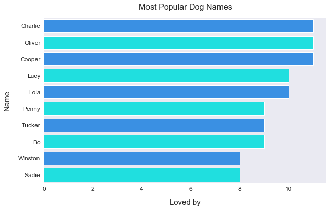

#### 2. What are the most common dog stages?

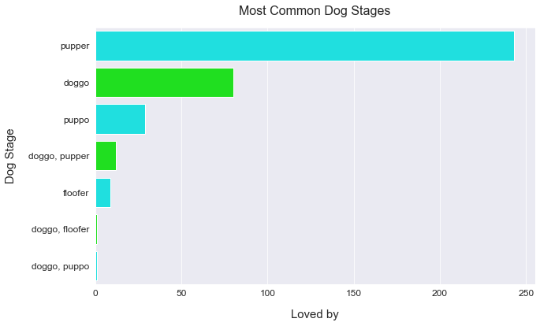

#### 3. What are apparently the most common dog breeds?

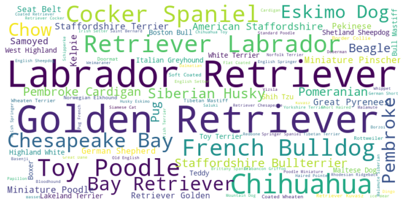

#### 4. What's the favorite day of week for @WeRateDogs to post something on their twitter handle?

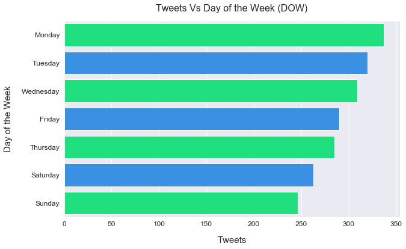

#### 5. At which our of the day @WeRateDogs posts the most, on their twitter handle?

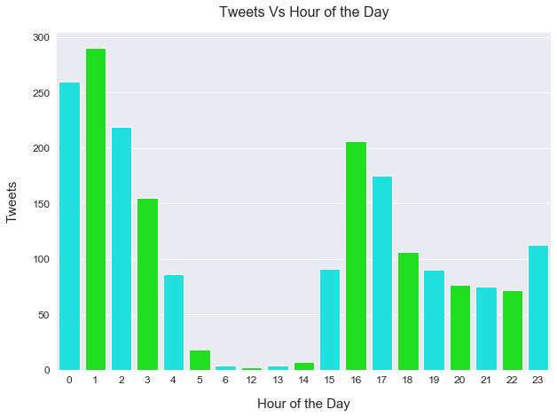

#### 6. Is there any correlation between retweet count and likes?

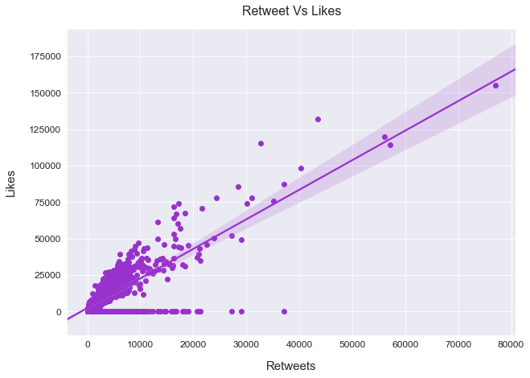